# EDA_CC

## EDA : Credit Card Payment Analysis

### Objective:

To analyze the dataset of customer details and their credit card payment history (April 2005 to September 2005) to extract insights on factors that distinguish credible from non-credible customers.

### Day1. Describe the Data

##### 1.1 Importing necessary libraries :

```python
import numpy as np                #for data manuplation
import pandas as pd               #for numerical operations
import matplotlib.pyplot as plt   #for plotting graphs
import seaborn as sns             #for advance plotting
import scipy

import warnings
warnings.simplefilter("ignore")
```

##### 1.2 Loadig Dataset:

```python
credit_card_df = pd.read_csv('C:/Users/nisha/Downloads/EDApython/credit_card_dataset.csv')
```

```python
# Sample data:
credit_card_df.sample(10)
```

|  | ID | LIMIT_BAL | GENDER | EDUCATION | MARRIAGE | AGE | PAY_1 | PAY_2 | PAY_3 | PAY_4 | ... | BILL_AMT4 | BILL_AMT5 | BILL_AMT6 | PAY_AMT1 | PAY_AMT2 | PAY_AMT3 | PAY_AMT4 | PAY_AMT5 | PAY_AMT6 | DEFAULT |
| --- | --- | --- | --- | --- | --- | --- | --- | --- | --- | --- | --- | --- | --- | --- | --- | --- | --- | --- | --- | --- | --- |
| 21688 | 21689 | 20000 | 2 | 1 | 2 | 24.0 | 0 | 0 | 0 | 0 | ... | 21813 | 21228 | 21614 | 2700 | 1400 | 1400 | 800 | 1783 | 1000 | 1 |
| 11898 | 11899 | 200000 | 2 | 3 | 2 | 29.0 | -1 | -1 | -1 | -1 | ... | 3678 | 32405 | 30943 | 1000 | 2244 | 3678 | 31996 | 1097 | 1579 | 0 |
| 22992 | 22993 | 310000 | 2 | 2 | 1 | 46.0 | -1 | -1 | -1 | -1 | ... | 843 | 857 | -777 | 423 | 430 | 845 | 857 | 628 | 0 | 0 |
| 10388 | 10389 | 10000 | 1 | 2 | 2 | 22.0 | 0 | 0 | 0 | 0 | ... | 8780 | 9114 | 9234 | 1134 | 1143 | 315 | 476 | 420 | 1000 | 1 |
| 15606 | 15607 | 130000 | 2 | 2 | 2 | 28.0 | 0 | 0 | 0 | 0 | ... | 116721 | 117795 | 120511 | 5500 | 5700 | 5692 | 4500 | 4850 | 3800 | 1 |
| 19406 | 19407 | 260000 | 2 | 2 | 1 | 36.0 | 0 | 0 | -1 | 0 | ... | 3976 | 6623 | 24426 | 2037 | 4979 | 1019 | 6623 | 18119 | 1382 | 0 |
| 2754 | 2755 | 20000 | 1 | 1 | 2 | 22.0 | 0 | 0 | 0 | 0 | ... | 5751 | 6500 | 7386 | 1100 | 1100 | 500 | 1000 | 1000 | 1000 | 0 |
| 28105 | 28106 | 180000 | 2 | 1 | 1 | 39.0 | -1 | -1 | -1 | -1 | ... | 13999 | 933 | 933 | 6846 | 18399 | 13999 | 933 | 933 | 993 | 0 |
| 14202 | 14203 | 230000 | 2 | 1 | 2 | 34.0 | -1 | 0 | 0 | 0 | ... | 2845 | 1935 | 6781 | 5000 | 1000 | 0 | 2000 | 5000 | 1000 | 0 |
| 7174 | 7175 | 20000 | 1 | 2 | 1 | 36.0 | 2 | 2 | 2 | 2 | ... | 22857 | 21143 | 21482 | 1700 | 0 | 1653 | 0 | 1940 | 0 | 0 |

10 rows × 25 columns

##### 1.3 Finding total numbers of rows and columns in dataset :

```python
credit_card_df.shape
```

```
(30000, 25)
```

##### 1.4 Checking the column data types :

```python
credit_card_df.info()
```

```
<class 'pandas.core.frame.DataFrame'>
RangeIndex: 30000 entries, 0 to 29999
Data columns (total 25 columns):
 #   Column     Non-Null Count  Dtype
---  ------     --------------  -----
 0   ID         30000 non-null  int64
 1   LIMIT_BAL  30000 non-null  int64
 2   GENDER     30000 non-null  int64
 3   EDUCATION  30000 non-null  int64
 4   MARRIAGE   30000 non-null  int64
 5   AGE        29990 non-null  float64
 6   PAY_1      30000 non-null  int64
 7   PAY_2      30000 non-null  int64
 8   PAY_3      30000 non-null  int64
 9   PAY_4      30000 non-null  int64
```

[output cut: 17 more lines]

##### 1.5 Basic summary statistics table for numerical and categorical features :

```python
credit_card_df.describe()
```

|  | ID | LIMIT_BAL | GENDER | EDUCATION | MARRIAGE | AGE | PAY_1 | PAY_2 | PAY_3 | PAY_4 | ... | BILL_AMT4 | BILL_AMT5 | BILL_AMT6 | PAY_AMT1 | PAY_AMT2 | PAY_AMT3 | PAY_AMT4 | PAY_AMT5 | PAY_AMT6 | DEFAULT |
| --- | --- | --- | --- | --- | --- | --- | --- | --- | --- | --- | --- | --- | --- | --- | --- | --- | --- | --- | --- | --- | --- |
| count | 30000.000000 | 30000.000000 | 30000.000000 | 30000.000000 | 30000.000000 | 29990.000000 | 30000.000000 | 30000.000000 | 30000.000000 | 30000.000000 | ... | 30000.000000 | 30000.000000 | 30000.000000 | 30000.000000 | 3.000000e+04 | 30000.00000 | 30000.000000 | 30000.000000 | 30000.000000 | 30000.000000 |
| mean | 15000.500000 | 167484.322667 | 1.603733 | 1.853133 | 1.551867 | 35.487062 | -0.016700 | -0.133767 | -0.166200 | -0.220667 | ... | 43262.948967 | 40311.400967 | 38871.760400 | 5663.580500 | 5.921163e+03 | 5225.68150 | 4826.076867 | 4799.387633 | 5215.502567 | 0.221200 |
| std | 8660.398374 | 129747.661567 | 0.489129 | 0.790349 | 0.521970 | 9.236845 | 1.123802 | 1.197186 | 1.196868 | 1.169139 | ... | 64332.856134 | 60797.155770 | 59554.107537 | 16563.280354 | 2.304087e+04 | 17606.96147 | 15666.159744 | 15278.305679 | 17777.465775 | 0.415062 |
| min | 1.000000 | 10000.000000 | 1.000000 | 0.000000 | 0.000000 | -20.000000 | -2.000000 | -2.000000 | -2.000000 | -2.000000 | ... | -170000.000000 | -81334.000000 | -339603.000000 | 0.000000 | 0.000000e+00 | 0.00000 | 0.000000 | 0.000000 | 0.000000 | 0.000000 |
| 25% | 7500.750000 | 50000.000000 | 1.000000 | 1.000000 | 1.000000 | 28.000000 | -1.000000 | -1.000000 | -1.000000 | -1.000000 | ... | 2326.750000 | 1763.000000 | 1256.000000 | 1000.000000 | 8.330000e+02 | 390.00000 | 296.000000 | 252.500000 | 117.750000 | 0.000000 |
| 50% | 15000.500000 | 140000.000000 | 2.000000 | 2.000000 | 2.000000 | 34.000000 | 0.000000 | 0.000000 | 0.000000 | 0.000000 | ... | 19052.000000 | 18104.500000 | 17071.000000 | 2100.000000 | 2.009000e+03 | 1800.00000 | 1500.000000 | 1500.000000 | 1500.000000 | 0.000000 |
| 75% | 22500.250000 | 240000.000000 | 2.000000 | 2.000000 | 2.000000 | 41.000000 | 0.000000 | 0.000000 | 0.000000 | 0.000000 | ... | 54506.000000 | 50190.500000 | 49198.250000 | 5006.000000 | 5.000000e+03 | 4505.00000 | 4013.250000 | 4031.500000 | 4000.000000 | 0.000000 |
| max | 30000.000000 | 1000000.000000 | 2.000000 | 6.000000 | 3.000000 | 120.000000 | 8.000000 | 8.000000 | 8.000000 | 8.000000 | ... | 891586.000000 | 927171.000000 | 961664.000000 | 873552.000000 | 1.684259e+06 | 896040.00000 | 621000.000000 | 426529.000000 | 528666.000000 | 1.000000 |

8 rows × 25 columns

##### 1.6 checking if any duplicate rows :

```python
credit_card_df.duplicated().sum()
```

```
0
```

#### DAY1 INSIGHTS :

- There are 30,000 rows and 25 columns.
- The dataset consist of only two datatype Float and Integer.
- Column Age is of Float datatype and rest of all the columns containd data of integer type.
- In dataset there were no duplicates were found.

### Day2. Data Preprocessing

##### 2.1 Renaming the columns for better understanding :

```python
credit_card_df.rename(columns={
    'PAY_1': 'September',
    'PAY_2': 'August',
    'PAY_3': 'July',
    'PAY_4': 'June',
    'PAY_5': 'May',
    'PAY_6': 'April'
}, inplace=True)
```

##### 2.2 Getting first and last 5 records :

```python
# First five records from dataframe
credit_card_df.head()
```

|  | ID | LIMIT_BAL | GENDER | EDUCATION | MARRIAGE | AGE | September | August | July | June | ... | BILL_AMT4 | BILL_AMT5 | BILL_AMT6 | PAY_AMT1 | PAY_AMT2 | PAY_AMT3 | PAY_AMT4 | PAY_AMT5 | PAY_AMT6 | DEFAULT |
| --- | --- | --- | --- | --- | --- | --- | --- | --- | --- | --- | --- | --- | --- | --- | --- | --- | --- | --- | --- | --- | --- |
| 0 | 1 | 20000 | 2 | 2 | 1 | 24.0 | 2 | 2 | -1 | -1 | ... | 0 | 0 | 0 | 0 | 689 | 0 | 0 | 0 | 0 | 1 |
| 1 | 2 | 120000 | 2 | 2 | 2 | 26.0 | -1 | 2 | 0 | 0 | ... | 3272 | 3455 | 3261 | 0 | 1000 | 1000 | 1000 | 0 | 2000 | 1 |
| 2 | 3 | 90000 | 2 | 2 | 2 | 34.0 | 0 | 0 | 0 | 0 | ... | 14331 | 14948 | 15549 | 1518 | 1500 | 1000 | 1000 | 1000 | 5000 | 0 |
| 3 | 4 | 50000 | 2 | 2 | 1 | 37.0 | 0 | 0 | 0 | 0 | ... | 28314 | 28959 | 29547 | 2000 | 2019 | 1200 | 1100 | 1069 | 1000 | 0 |
| 4 | 5 | 50000 | 1 | 2 | 1 | 57.0 | -1 | 0 | -1 | 0 | ... | 20940 | 19146 | 19131 | 2000 | 36681 | 10000 | 9000 | 689 | 679 | 0 |

5 rows × 25 columns

```python
# Last five records from dataframe
credit_card_df.tail()
```

|  | ID | LIMIT_BAL | GENDER | EDUCATION | MARRIAGE | AGE | September | August | July | June | ... | BILL_AMT4 | BILL_AMT5 | BILL_AMT6 | PAY_AMT1 | PAY_AMT2 | PAY_AMT3 | PAY_AMT4 | PAY_AMT5 | PAY_AMT6 | DEFAULT |
| --- | --- | --- | --- | --- | --- | --- | --- | --- | --- | --- | --- | --- | --- | --- | --- | --- | --- | --- | --- | --- | --- |
| 29995 | 29996 | 220000 | 1 | 3 | 1 | 39.0 | 0 | 0 | 0 | 0 | ... | 88004 | 31237 | 15980 | 8500 | 20000 | 5003 | 3047 | 5000 | 1000 | 0 |
| 29996 | 29997 | 150000 | 1 | 3 | 2 | 43.0 | -1 | -1 | -1 | -1 | ... | 8979 | 5190 | 0 | 1837 | 3526 | 8998 | 129 | 0 | 0 | 0 |
| 29997 | 29998 | 30000 | 1 | 2 | 2 | 37.0 | 4 | 3 | 2 | -1 | ... | 20878 | 20582 | 19357 | 0 | 0 | 22000 | 4200 | 2000 | 3100 | 1 |
| 29998 | 29999 | 80000 | 1 | 3 | 1 | 41.0 | 1 | -1 | 0 | 0 | ... | 52774 | 11855 | 48944 | 85900 | 3409 | 1178 | 1926 | 52964 | 1804 | 1 |
| 29999 | 30000 | 50000 | 1 | 2 | 1 | 46.0 | 0 | 0 | 0 | 0 | ... | 36535 | 32428 | 15313 | 2078 | 1800 | 1430 | 1000 | 1000 | 1000 | 1 |

5 rows × 25 columns

##### 2.3 Converting Integer datatype into Categorical datatype :

```python
credit_card_df[['GENDER', 'EDUCATION', 'MARRIAGE', 'DEFAULT']] = credit_card_df[['GENDER', 'EDUCATION', 'MARRIAGE', 'DEFAULT']].astype('category')

credit_card_df[['September','August','July','June','May','April']] = credit_card_df[['September','August','July','June','May','April']].astype('category')
```

```python
credit_card_df.dtypes
```

```
ID              int64
LIMIT_BAL       int64
GENDER       category
EDUCATION    category
MARRIAGE     category
AGE           float64
September    category
August       category
July         category
June         category
May          category
April        category
BILL_AMT1       int64
BILL_AMT2       int64
BILL_AMT3       int64
BILL_AMT4       int64
BILL_AMT5       int64
BILL_AMT6       int64
PAY_AMT1        int64
PAY_AMT2        int64
PAY_AMT3        int64
PAY_AMT4        int64
PAY_AMT5        int64
PAY_AMT6        int64
DEFAULT      category
dtype: object
```

Now in dataset there are : 1 float, 10 Categorical, 14 int

##### 2.4 Finding missing values and Anamolies :

```python
# checking for missing or null values in dataset.
credit_card_df.isnull().sum()
```

```
ID            0
LIMIT_BAL     0
GENDER        0
EDUCATION     0
MARRIAGE      0
AGE          10
September     0
August        0
July          0
June          0
May           0
April         0
BILL_AMT1     0
BILL_AMT2     0
BILL_AMT3     0
BILL_AMT4     0
BILL_AMT5     0
BILL_AMT6     0
PAY_AMT1      0
PAY_AMT2      0
PAY_AMT3      0
PAY_AMT4      0
PAY_AMT5      0
PAY_AMT6      0
DEFAULT       0
dtype: int64
```

So, we can see that only feature 'AGE' has null values.

```python
# Finding rows where 'AGE' is not between 18 and 90
invalid_age = credit_card_df[(credit_card_df['AGE'] < 18) | (credit_card_df['AGE'] > 90)]
invalid_age
```

|  | ID | LIMIT_BAL | GENDER | EDUCATION | MARRIAGE | AGE | September | August | July | June | ... | BILL_AMT4 | BILL_AMT5 | BILL_AMT6 | PAY_AMT1 | PAY_AMT2 | PAY_AMT3 | PAY_AMT4 | PAY_AMT5 | PAY_AMT6 | DEFAULT |
| --- | --- | --- | --- | --- | --- | --- | --- | --- | --- | --- | --- | --- | --- | --- | --- | --- | --- | --- | --- | --- | --- |
| 409 | 410 | 280000 | 1 | 1 | 2 | -20.0 | 0 | 0 | 0 | 0 | ... | 182672 | 168399 | 167983 | 10000 | 8000 | 6371 | 6217 | 5947 | 6288 | 0 |
| 430 | 431 | 90000 | 2 | 2 | 2 | 120.0 | 0 | 0 | 0 | 0 | ... | 74424 | 76070 | 77648 | 3200 | 3300 | 3000 | 3001 | 3000 | 3100 | 0 |

2 rows × 25 columns

There are 2 values in 'AGE' column which are not in range between 18 to 90.

##### 2.5 Treating anomalies and missing values :

```python
# Step 1: Replace invalid ages with NaN (values < 18 or > 90)

credit_card_df['AGE'] = credit_card_df['AGE'].apply(lambda x: np.nan if (x < 18 or x > 90) else x)
```

```python
# Step 2: Handle NaN values by fill NaN values with the mean age

credit_card_df['AGE'].fillna(credit_card_df['AGE'].mean(), inplace=True)
```

```python
# Unique values in each columns :
for column in credit_card_df.columns:
    unique_values = credit_card_df[column].unique()
    print(f"Unique values in column '{column}': {unique_values}")
```

```
Unique values in column 'ID': [    1     2     3 ... 29998 29999 30000]
Unique values in column 'LIMIT_BAL': [  20000  120000   90000   50000  500000  100000  140000  200000  260000
  630000   70000  250000  320000  360000  180000  130000  450000   60000
  230000  160000  280000   10000   40000  210000  150000  380000  310000
  400000   80000  290000  340000  300000   30000  240000  470000  480000
  350000  330000  110000  420000  170000  370000  270000  220000  190000
  510000  460000  440000  410000  490000  390000  580000  600000  620000
  610000  700000  670000  680000  430000  550000  540000 1000000  530000
  710000  560000  520000  750000  640000   16000  570000  590000  660000
  720000  327680  740000  800000  760000  690000  650000  780000  730000]
Unique values in column 'GENDER': [2, 1]
Categories (2, int64): [1, 2]
Unique values in column 'EDUCATION': [2, 1, 3, 5, 4, 6, 0]
Categories (7, int64): [0, 1, 2, 3, 4, 5, 6]
Unique values in column 'MARRIAGE': [1, 2, 3, 0]
Categories (4, int64): [0, 1, 2, 3]
Unique values in column 'AGE': [24.         26.         34.         37.         57.         35.48609444
 29.         23.         28.         35.         51.         41.
 30.         49.         39.         40.         27.         47.
 32.         54.         58.         22.         25.         31.
 33.         46.         42.         43.         45.         56.
 44.         53.         38.         63.         36.         52.
 48.         55.         60.         50.         75.         61.
 73.         59.         21.         67.         66.         62.
 70.         72.         64.         65.         71.         69.
 68.         79.         74.        ]
Unique values in column 'September': [2, -1, 0, -2, 1, ..., 4, 8, 7, 5, 6]
Length: 11
Categories (11, int64): [-2, -1, 0, 1, ..., 5, 6, 7, 8]
Unique values in column 'August': [2, 0, -1, -2, 3, ..., 7, 4, 1, 6, 8]
Length: 11
Categories (11, int64): [-2, -1, 0, 1, ..., 5, 6, 7, 8]
Unique values in column 'July': [-1, 0, 2, -2, 3, ..., 6, 7, 1, 5, 8]
Length: 11
Categories (11, int64): [-2, -1, 0, 1, ..., 5, 6, 7, 8]
Unique values in column 'June': [-1, 0, -2, 2, 3, ..., 5, 7, 6, 1, 8]
Length: 11
Categories (11, int64): [-2, -1, 0, 1, ..., 5, 6, 7, 8]
Unique values in column 'May': [-2, 0, -1, 2, 3, 5, 4, 7, 8, 6]
Categories (10, int64): [-2, -1, 0, 2, ..., 5, 6, 7, 8]
Unique values in column 'April': [-2, 2, 0, -1, 3, 6, 4, 7, 8, 5]
Categories (10, int64): [-2, -1, 0, 2, ..., 5, 6, 7, 8]
Unique values in column 'BILL_AMT1': [ 3913  2682 29239 ...  1683 -1645 47929]
Unique values in column 'BILL_AMT2': [ 3102  1725 14027 ...  3356 78379 48905]
Unique values in column 'BILL_AMT3': [  689  2682 13559 ...  2758 76304 49764]
Unique values in column 'BILL_AMT4': [    0  3272 14331 ... 20878 52774 36535]
Unique values in column 'BILL_AMT5': [    0  3455 14948 ... 31237  5190 32428]
Unique values in column 'BILL_AMT6': [    0  3261 15549 ... 19357 48944 15313]
Unique values in column 'PAY_AMT1': [    0  1518  2000 ... 10029  9054 85900]
Unique values in column 'PAY_AMT2': [   689   1000   1500 ...   2977 111784   3526]
Unique values in column 'PAY_AMT3': [     0   1000   1200 ... 349395   8907  25128]
Unique values in column 'PAY_AMT4': [    0  1000  1100 ...  2556 10115  8049]
Unique values in column 'PAY_AMT5': [    0  1000  1069 ...  8040  3319 52964]
Unique values in column 'PAY_AMT6': [     0   2000   5000 ...  70052 220076  16080]
Unique values in column 'DEFAULT': [1, 0]
Categories (2, int64): [0, 1]
```

```python
credit_card_df['EDUCATION'].value_counts()
```

```
EDUCATION
2    14030
1    10585
3     4917
5      280
4      123
6       51
0       14
Name: count, dtype: int64
```

```python
credit_card_df['MARRIAGE'].value_counts()
```

```
MARRIAGE
2    15964
1    13659
3      323
0       54
Name: count, dtype: int64
```

From above observations :

- As per data dictionary provided in column 'Education' there should be only categorie value[1,2,3,4,5,6] but we can identify that there is one extra value or categorie value '0'.
- And same situation can be identify in column 'Marrige'.

##### 2.6 Treating categorial values :

```python
# Replace values in the 'GENDER' column: 1 -> 'M', 2 -> 'F'
gender_mapping = {1: 'M', 2: 'F'}

# Applying the mapping
credit_card_df['GENDER'] = credit_card_df['GENDER'].map(gender_mapping)
```

```python
# Mapping for EDUCATION
education_mapping = {1: 'Graduate_school', 2: 'University', 3: 'High_School', 4: 'Others', 5:'Unknown', 6:'Unknown',0:'Not Specified'}

credit_card_df['EDUCATION'] = credit_card_df['EDUCATION'].map(education_mapping)
```

```python
# Mapping for MARRIAGE
marriage_mapping = {1: 'Married', 2: 'Single', 3: 'Others',0:'Not Specified'}

credit_card_df['MARRIAGE'] = credit_card_df['MARRIAGE'].map(marriage_mapping)
```

```python
# Mapping for Default
default_mapping = {1: 'Yes', 0: 'No'}

# Applying the mapping
credit_card_df['DEFAULT'] = credit_card_df['DEFAULT'].map(default_mapping)
```

```python
# Mapping for columns:'September','August','July','June','May','April'

# Define the mapping
repayment_mapping = {
    -2: 'InactiveAc',
    -1: 'Paid_Duly',
     0: 'Revolving_Credit',
     1: 'Paymt_Delay1M',
     2: 'Paymt_Delay2M',
     3: 'Paymt_Delay3M',
     4: 'Paymt_Delay4M',
     5: 'Paymt_Delay5M',
     6: 'Paymt_Delay6M',
     7: 'Paymt_Delay7M',
     8: 'Paymt_Delay8M',
     9: 'Paymt_Delay9M&more'
}

# Map the repayment status
for column in ['September','August','July','June','May','April']:
    credit_card_df[column] = credit_card_df[column].map(repayment_mapping)
```

##### 2.7 Checking Anamolies for 'Bill amount' and 'Pay amount' in last 6 month :

```python
# List of columns to check
columns_to_check = [
    'BILL_AMT1', 'BILL_AMT2', 'BILL_AMT3', 'BILL_AMT4', 'BILL_AMT5', 'BILL_AMT6',
    'PAY_AMT1', 'PAY_AMT2', 'PAY_AMT3', 'PAY_AMT4', 'PAY_AMT5', 'PAY_AMT6'
]

# Count negative values in each specified column
negative_counts = (credit_card_df[columns_to_check] < 0).sum()
negative_counts
```

```
BILL_AMT1    590
BILL_AMT2    669
BILL_AMT3    655
BILL_AMT4    675
BILL_AMT5    655
BILL_AMT6    688
PAY_AMT1       0
PAY_AMT2       0
PAY_AMT3       0
PAY_AMT4       0
PAY_AMT5       0
PAY_AMT6       0
dtype: int64
```

So, only Bill amount of last 6 months contains negative values.

##### 2.8 Addressing outliers :

###### i. Dectecting in column LIMIT_BAL :

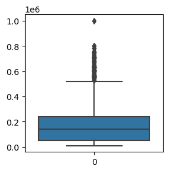

```python
# Boxplots to detect outliers for LIMIT_BAL
plt.figure(figsize=(3, 3))
sns.boxplot(data=credit_card_df['LIMIT_BAL'])
plt.show()
```

##### Observation :

the feature 'LIMIT_BAL' which consist total amount of credit both personal and his/her family has outliers.

###### Finding outliers using IQR.

```python
credit_card_df['LIMIT_BAL'].describe()
```

```
count      30000.000000
mean      167484.322667
std       129747.661567
min        10000.000000
25%        50000.000000
50%       140000.000000
75%       240000.000000
max      1000000.000000
Name: LIMIT_BAL, dtype: float64
```

```python
# finding IQR
percentile25 = credit_card_df['LIMIT_BAL'].quantile(0.25)   #calculating 25th percentile
percentile75 = credit_card_df['LIMIT_BAL'].quantile(0.75)   #calculating 75th percentile
```

```python
IQR = percentile75 - percentile25  #calculating IQR
IQR
```

```
190000.0
```

```python
upper_limit = percentile75 + 1.5 * IQR   #calculating upper limite
lower_limit = percentile25 - 1.5 * IQR   #calculating lower limite
print('upper_limit :',upper_limit)
print('lower_limit :',lower_limit)
```

```
upper_limit : 525000.0
lower_limit : -235000.0
```

```python
# finding outliers
credit_card_df[credit_card_df['LIMIT_BAL']>upper_limit]
```

|  | ID | LIMIT_BAL | GENDER | EDUCATION | MARRIAGE | AGE | September | August | July | June | ... | BILL_AMT4 | BILL_AMT5 | BILL_AMT6 | PAY_AMT1 | PAY_AMT2 | PAY_AMT3 | PAY_AMT4 | PAY_AMT5 | PAY_AMT6 | DEFAULT |
| --- | --- | --- | --- | --- | --- | --- | --- | --- | --- | --- | --- | --- | --- | --- | --- | --- | --- | --- | --- | --- | --- |
| 12 | 13 | 630000 | F | University | Single | 41.0 | Paid_Duly | Revolving_Credit | Paid_Duly | Paid_Duly | ... | 6500 | 6500 | 2870 | 1000 | 6500 | 6500 | 6500 | 2870 | 0 | No |
| 433 | 434 | 580000 | F | Graduate_school | Married | 36.0 | Revolving_Credit | Revolving_Credit | Revolving_Credit | Revolving_Credit | ... | 169365 | 168755 | 167964 | 6422 | 6565 | 5951 | 6006 | 5894 | 5946 | No |
| 451 | 452 | 600000 | M | Graduate_school | Married | 53.0 | Paymt_Delay2M | Paymt_Delay2M | Revolving_Credit | Revolving_Credit | ... | 447130 | 440982 | 434715 | 0 | 18000 | 16000 | 16000 | 21000 | 20000 | Yes |
| 527 | 528 | 620000 | F | University | Married | 45.0 | Paymt_Delay2M | Paymt_Delay2M | Revolving_Credit | Revolving_Credit | ... | 163781 | 167159 | 170894 | 0 | 6200 | 6000 | 6000 | 6500 | 6000 | Yes |
| 555 | 556 | 630000 | F | University | Married | 47.0 | Revolving_Credit | Revolving_Credit | Revolving_Credit | Paid_Duly | ... | 2632 | 8654 | 0 | 38187 | 1207 | 2632 | 8654 | 0 | 4981 | No |
| ... | ... | ... | ... | ... | ... | ... | ... | ... | ... | ... | ... | ... | ... | ... | ... | ... | ... | ... | ... | ... | ... |
| 29571 | 29572 | 570000 | M | Graduate_school | Single | 33.0 | Revolving_Credit | Revolving_Credit | Revolving_Credit | Revolving_Credit | ... | 266800 | 0 | 0 | 9083 | 11472 | 12000 | 0 | 0 | 0 | No |
| 29740 | 29741 | 620000 | M | University | Single | 31.0 | InactiveAc | InactiveAc | InactiveAc | InactiveAc | ... | 13846 | 3565 | 7076 | 11881 | 21171 | 13915 | 3583 | 7111 | 1971 | No |
| 29861 | 29862 | 650000 | M | Graduate_school | Married | 44.0 | InactiveAc | InactiveAc | InactiveAc | InactiveAc | ... | 7139 | 1034 | 2127 | 5115 | 5180 | 7201 | 1035 | 2139 | 3463 | No |
| 29886 | 29887 | 630000 | M | University | Married | 46.0 | Revolving_Credit | Revolving_Credit | Revolving_Credit | Revolving_Credit | ... | 146005 | 146207 | 106467 | 3416 | 4300 | 84700 | 4211 | 4470 | 3600 | No |
| 29963 | 29964 | 610000 | M | Graduate_school | Single | 31.0 | Revolving_Credit | Paid_Duly | Paymt_Delay2M | Paid_Duly | ... | 347303 | 248893 | 269528 | 323014 | 1605 | 349395 | 250144 | 271099 | 220076 | No |

167 rows × 25 columns

```python
credit_card_df[credit_card_df['LIMIT_BAL']<lower_limit]
```

|  | ID | LIMIT_BAL | GENDER | EDUCATION | MARRIAGE | AGE | September | August | July | June | ... | BILL_AMT4 | BILL_AMT5 | BILL_AMT6 | PAY_AMT1 | PAY_AMT2 | PAY_AMT3 | PAY_AMT4 | PAY_AMT5 | PAY_AMT6 | DEFAULT |
| --- | --- | --- | --- | --- | --- | --- | --- | --- | --- | --- | --- | --- | --- | --- | --- | --- | --- | --- | --- | --- | --- |

0 rows × 25 columns

###### Treating outliers using Capping method:

```python
# Capping to treate the outliers in column 'LIMIT_BAL'

credit_card_df = credit_card_df.copy()

credit_card_df['LIMIT_BAL'] = np.where(
    credit_card_df['LIMIT_BAL']>upper_limit,
    upper_limit,
    np.where(
        credit_card_df['LIMIT_BAL']<lower_limit,
        lower_limit,
        credit_card_df['LIMIT_BAL']
    )
)
```

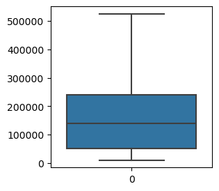

```python
# Boxplots after treating outliers in LIMIT_BAL
plt.figure(figsize=(3, 3))
sns.boxplot(data=credit_card_df['LIMIT_BAL'])
plt.show()
```

###### ii. Dectecting outliers for bill amount for last 6 months :

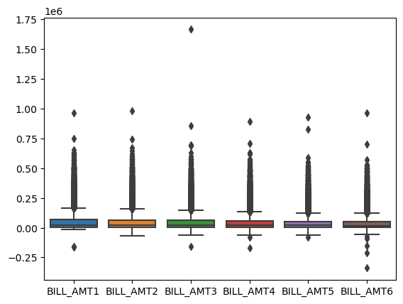

```python
# Boxplots to detect outliers for bill amount for last 6 months
sns.boxplot(data=credit_card_df[['BILL_AMT1', 'BILL_AMT2', 'BILL_AMT3', 'BILL_AMT4', 'BILL_AMT5', 'BILL_AMT6']])
plt.show()
```

##### Observation :

In all the 6 bill amount columns consist of outliers.

```python
#Getting statistical information of bill amount for last 6 months
credit_card_df[['BILL_AMT1', 'BILL_AMT2', 'BILL_AMT3', 'BILL_AMT4', 'BILL_AMT5', 'BILL_AMT6']].describe()
```

|  | BILL_AMT1 | BILL_AMT2 | BILL_AMT3 | BILL_AMT4 | BILL_AMT5 | BILL_AMT6 |
| --- | --- | --- | --- | --- | --- | --- |
| count | 30000.000000 | 30000.000000 | 3.000000e+04 | 30000.000000 | 30000.000000 | 30000.000000 |
| mean | 51223.330900 | 49179.075167 | 4.701315e+04 | 43262.948967 | 40311.400967 | 38871.760400 |
| std | 73635.860576 | 71173.768783 | 6.934939e+04 | 64332.856134 | 60797.155770 | 59554.107537 |
| min | -165580.000000 | -69777.000000 | -1.572640e+05 | -170000.000000 | -81334.000000 | -339603.000000 |
| 25% | 3558.750000 | 2984.750000 | 2.666250e+03 | 2326.750000 | 1763.000000 | 1256.000000 |
| 50% | 22381.500000 | 21200.000000 | 2.008850e+04 | 19052.000000 | 18104.500000 | 17071.000000 |
| 75% | 67091.000000 | 64006.250000 | 6.016475e+04 | 54506.000000 | 50190.500000 | 49198.250000 |
| max | 964511.000000 | 983931.000000 | 1.664089e+06 | 891586.000000 | 927171.000000 | 961664.000000 |

###### Finding outliers using IQR

Here, I have tried to find outliers of each feature togather using loop.

```python
# Define the numeric columns for which to calculate IQR
billamt_features = ['BILL_AMT1', 'BILL_AMT2', 'BILL_AMT3', 'BILL_AMT4', 'BILL_AMT5', 'BILL_AMT6']

# Initialize an empty dictionary to store the IQR, upper, and lower limits for each column
iqr_billamt = {}

# Loop through each feature
for feature in billamt_features:
    # Calculate the 25th and 75th percentiles (Q1 and Q3)
    Q1 = credit_card_df[feature].quantile(0.25)
    Q3 = credit_card_df[feature].quantile(0.75)

    # Calculate the IQR
    IQR = Q3 - Q1

    # Calculate the upper and lower limits for outliers
    upper_limit = Q3 + 1.5 * IQR
    lower_limit = Q1 - 1.5 * IQR

    # Store the results in the dictionary
    iqr_billamt[feature] = {
        'Q1': Q1,
        'Q3': Q3,
        'IQR': IQR,
        'upper_limit': upper_limit,
        'lower_limit': lower_limit
    }

    # Print the IQR and limits for each feature
    print(f'{feature} -> Q1: {Q1}, Q3: {Q3}, IQR: {IQR}, Upper Limit: {upper_limit}, Lower Limit: {lower_limit}')

    # Identify outliers for the current column
    outliers = credit_card_df[(credit_card_df[feature] < lower_limit) | (credit_card_df[feature] > upper_limit)]
    print(f"Number of outliers in {feature}: {outliers.shape[0]}")
```

```
BILL_AMT1 -> Q1: 3558.75, Q3: 67091.0, IQR: 63532.25, Upper Limit: 162389.375, Lower Limit: -91739.625
Number of outliers in BILL_AMT1: 2400
BILL_AMT2 -> Q1: 2984.75, Q3: 64006.25, IQR: 61021.5, Upper Limit: 155538.5, Lower Limit: -88547.5
Number of outliers in BILL_AMT2: 2395
BILL_AMT3 -> Q1: 2666.25, Q3: 60164.75, IQR: 57498.5, Upper Limit: 146412.5, Lower Limit: -83581.5
Number of outliers in BILL_AMT3: 2469
BILL_AMT4 -> Q1: 2326.75, Q3: 54506.0, IQR: 52179.25, Upper Limit: 132774.875, Lower Limit: -75942.125
Number of outliers in BILL_AMT4: 2622
BILL_AMT5 -> Q1: 1763.0, Q3: 50190.5, IQR: 48427.5, Upper Limit: 122831.75, Lower Limit: -70878.25
Number of outliers in BILL_AMT5: 2725
BILL_AMT6 -> Q1: 1256.0, Q3: 49198.25, IQR: 47942.25, Upper Limit: 121111.625, Lower Limit: -70657.375
Number of outliers in BILL_AMT6: 2693
```

###### Treating outliers using Capping method:

```python
# Remove outliers from the dataset using capping method:
for feature in billamt_features:
    Q1 = credit_card_df[feature].quantile(0.25)
    Q3 = credit_card_df[feature].quantile(0.75)
    IQR = Q3 - Q1
    upper_limit = Q3 + 1.5 * IQR
    lower_limit = Q1 - 1.5 * IQR

    # Cap the values
    credit_card_df[feature] = credit_card_df[feature].apply(lambda x: upper_limit if x > upper_limit else lower_limit if x < lower_limit else x)
```

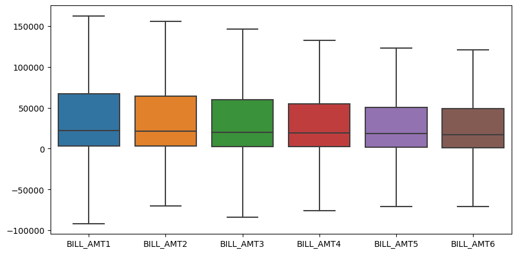

```python
# Boxplots after treating outliers of bill amount for last 6 months
plt.figure(figsize=(10, 5))
sns.boxplot(data=credit_card_df[['BILL_AMT1', 'BILL_AMT2', 'BILL_AMT3', 'BILL_AMT4', 'BILL_AMT5', 'BILL_AMT6']])
plt.show()
```

###### ii. Dectecting outliers for pay amount for last 6 months :

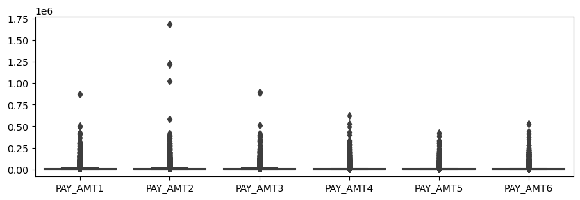

```python
# Boxplots to detect outliers for pay amount for last 6 months.
plt.figure(figsize=(10, 3))
sns.boxplot(data=credit_card_df[['PAY_AMT1', 'PAY_AMT2', 'PAY_AMT3', 'PAY_AMT4', 'PAY_AMT5', 'PAY_AMT6']])
plt.show()
```